# Risk Factor Analysis

## Outcome Variable

**Outcome Variable:** co_occurence

## Predictor Variables

**Intervention Variable:** ever_wasted06

**Adjustment Set:**

unadjusted

## Stratifying Variables

The analysis was stratified on these variable(s):

- studyid
- country

## Data Summary

| studyid | country | ever_wasted06 | co_occurence | n_cell | n | outcome_variable |
| --- | --- | --- | --- | --- | --- | --- |
| CMC-V-BCS-2002 | INDIA | 0 | 0 | 171 | 366 | co_occurence |
| CMC-V-BCS-2002 | INDIA | 0 | 1 | 4 | 366 | co_occurence |
| CMC-V-BCS-2002 | INDIA | 1 | 0 | 173 | 366 | co_occurence |
| CMC-V-BCS-2002 | INDIA | 1 | 1 | 18 | 366 | co_occurence |
| CMIN | BANGLADESH | 0 | 0 | 179 | 237 | co_occurence |
| CMIN | BANGLADESH | 0 | 1 | 17 | 237 | co_occurence |
| CMIN | BANGLADESH | 1 | 0 | 32 | 237 | co_occurence |
| CMIN | BANGLADESH | 1 | 1 | 9 | 237 | co_occurence |
| COHORTS | GUATEMALA | 0 | 0 | 594 | 774 | co_occurence |
| COHORTS | GUATEMALA | 0 | 1 | 26 | 774 | co_occurence |
| COHORTS | GUATEMALA | 1 | 0 | 142 | 774 | co_occurence |
| COHORTS | GUATEMALA | 1 | 1 | 12 | 774 | co_occurence |
| COHORTS | PHILIPPINES | 0 | 0 | 1777 | 2487 | co_occurence |
| COHORTS | PHILIPPINES | 0 | 1 | 112 | 2487 | co_occurence |
| COHORTS | PHILIPPINES | 1 | 0 | 523 | 2487 | co_occurence |
| COHORTS | PHILIPPINES | 1 | 1 | 75 | 2487 | co_occurence |
| CONTENT | PERU | 0 | 0 | 197 | 200 | co_occurence |
| CONTENT | PERU | 0 | 1 | 0 | 200 | co_occurence |
| CONTENT | PERU | 1 | 0 | 3 | 200 | co_occurence |
| CONTENT | PERU | 1 | 1 | 0 | 200 | co_occurence |
| EE | PAKISTAN | 0 | 0 | 190 | 346 | co_occurence |
| EE | PAKISTAN | 0 | 1 | 35 | 346 | co_occurence |
| EE | PAKISTAN | 1 | 0 | 82 | 346 | co_occurence |
| EE | PAKISTAN | 1 | 1 | 39 | 346 | co_occurence |
| GMS-Nepal | NEPAL | 0 | 0 | 302 | 550 | co_occurence |
| GMS-Nepal | NEPAL | 0 | 1 | 28 | 550 | co_occurence |
| GMS-Nepal | NEPAL | 1 | 0 | 188 | 550 | co_occurence |
| GMS-Nepal | NEPAL | 1 | 1 | 32 | 550 | co_occurence |
| IRC | INDIA | 0 | 0 | 175 | 405 | co_occurence |
| IRC | INDIA | 0 | 1 | 10 | 405 | co_occurence |

[output cut: 78 more lines]

The following strata were considered:

- studyid: CMC-V-BCS-2002, country: INDIA
- studyid: CMIN, country: BANGLADESH
- studyid: COHORTS, country: GUATEMALA
- studyid: COHORTS, country: PHILIPPINES
- studyid: CONTENT, country: PERU
- studyid: EE, country: PAKISTAN
- studyid: GMS-Nepal, country: NEPAL
- studyid: IRC, country: INDIA
- studyid: JiVitA-4, country: BANGLADESH
- studyid: Keneba, country: GAMBIA
- studyid: LCNI-5, country: MALAWI
- studyid: MAL-ED, country: BANGLADESH
- studyid: MAL-ED, country: BRAZIL
- studyid: MAL-ED, country: INDIA
- studyid: MAL-ED, country: NEPAL
- studyid: MAL-ED, country: PERU
- studyid: MAL-ED, country: SOUTH AFRICA
- studyid: MAL-ED, country: TANZANIA, UNITED REPUBLIC OF
- studyid: NIH-Birth, country: BANGLADESH
- studyid: NIH-Crypto, country: BANGLADESH
- studyid: PROBIT, country: BELARUS
- studyid: PROVIDE, country: BANGLADESH
- studyid: ResPak, country: PAKISTAN
- studyid: SAS-CompFeed, country: INDIA
- studyid: SAS-FoodSuppl, country: INDIA
- studyid: TanzaniaChild2, country: TANZANIA, UNITED REPUBLIC OF
- studyid: ZVITAMBO, country: ZIMBABWE

### Dropped Strata

Some strata were dropped due to rare outcomes:

- studyid: CMC-V-BCS-2002, country: INDIA
- studyid: CONTENT, country: PERU
- studyid: LCNI-5, country: MALAWI
- studyid: MAL-ED, country: BANGLADESH
- studyid: MAL-ED, country: BRAZIL
- studyid: MAL-ED, country: INDIA
- studyid: MAL-ED, country: NEPAL
- studyid: MAL-ED, country: PERU
- studyid: MAL-ED, country: SOUTH AFRICA
- studyid: MAL-ED, country: TANZANIA, UNITED REPUBLIC OF
- studyid: PROBIT, country: BELARUS
- studyid: ResPak, country: PAKISTAN

## Methods Detail

We’re interested in the causal parameters $E[Y_a]$ for all values of $a \in \mathcal{A}$. These parameters represent the mean outcome if, possibly contrary to fact, we intervened to set all units to have $A=a$. Under the randomization and positivity assumptions, these are identified by the statistical parameters $\psi_a=E_W[E_{Y|A,W}(Y|A=a,W)]$. In addition, we’re interested in the mean of $Y$, $E[Y]$ under no intervention (the observed mean). We will estimate these parameters by using SuperLearner to fit the relevant likelihood factors – $E_{Y|A,W}(Y|A=a,W)$ and $p(A=a|W)$, and then updating our likelihood fit using a joint TMLE.

For unadjusted analyses ($W=\{\}$), initial likelihoods were estimated using Lrnr_glm to estimate the simple $E(Y|A)$ and Lrnr_mean to estimate $p(A)$. For adjusted analyses, a small library containing Lrnr_glmnet, Lrnr_xgboost, and Lrnr_mean was used.

Having estimated these parameters, we will then use the delta method to estimate relative risks and attributable risks relative to a prespecified baseline level of $A$.

# Results Detail

## Results Plots

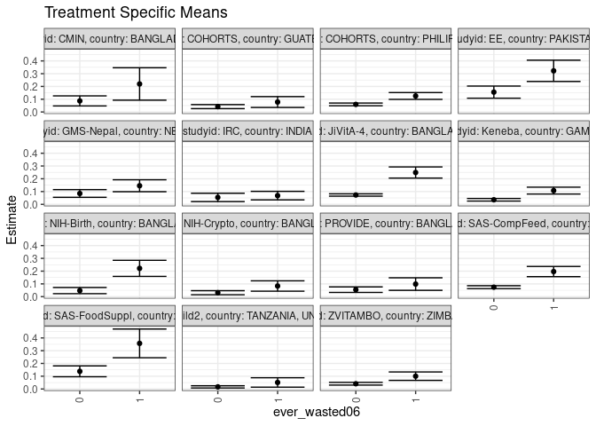

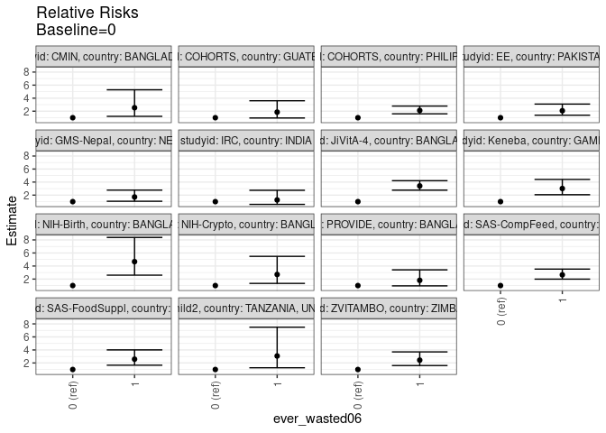

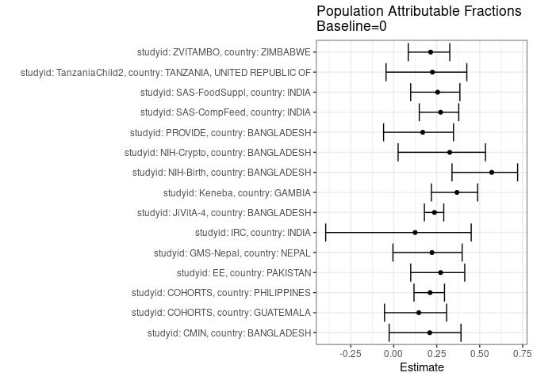

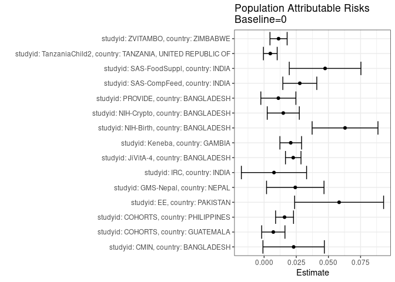

## Results Table

### Parameter: TSM

| studyid | country | intervention_level | baseline_level | estimate | ci_lower | ci_upper |
| --- | --- | --- | --- | --- | --- | --- |
| CMIN | BANGLADESH | 0 | NA | 0.0867347 | 0.0472496 | 0.1262198 |
| CMIN | BANGLADESH | 1 | NA | 0.2195122 | 0.0925464 | 0.3464780 |
| COHORTS | GUATEMALA | 0 | NA | 0.0419355 | 0.0261477 | 0.0577233 |
| COHORTS | GUATEMALA | 1 | NA | 0.0779221 | 0.0355595 | 0.1202847 |
| COHORTS | PHILIPPINES | 0 | NA | 0.0592906 | 0.0486384 | 0.0699429 |
| COHORTS | PHILIPPINES | 1 | NA | 0.1254181 | 0.0988680 | 0.1519681 |
| EE | PAKISTAN | 0 | NA | 0.1555556 | 0.1081299 | 0.2029812 |
| EE | PAKISTAN | 1 | NA | 0.3223140 | 0.2389195 | 0.4057086 |
| GMS-Nepal | NEPAL | 0 | NA | 0.0848485 | 0.0547562 | 0.1149407 |
| GMS-Nepal | NEPAL | 1 | NA | 0.1454545 | 0.0988248 | 0.1920843 |
| IRC | INDIA | 0 | NA | 0.0540541 | 0.0214294 | 0.0866787 |
| IRC | INDIA | 1 | NA | 0.0681818 | 0.0348335 | 0.1015301 |
| JiVitA-4 | BANGLADESH | 0 | NA | 0.0730038 | 0.0639461 | 0.0820615 |
| JiVitA-4 | BANGLADESH | 1 | NA | 0.2491409 | 0.2054610 | 0.2928208 |
| Keneba | GAMBIA | 0 | NA | 0.0356295 | 0.0254037 | 0.0458552 |
| Keneba | GAMBIA | 1 | NA | 0.1074219 | 0.0805928 | 0.1342509 |
| NIH-Birth | BANGLADESH | 0 | NA | 0.0474576 | 0.0231690 | 0.0717462 |
| NIH-Birth | BANGLADESH | 1 | NA | 0.2215569 | 0.1585023 | 0.2846114 |
| NIH-Crypto | BANGLADESH | 0 | NA | 0.0308370 | 0.0149223 | 0.0467517 |
| NIH-Crypto | BANGLADESH | 1 | NA | 0.0833333 | 0.0429251 | 0.1237416 |
| PROVIDE | BANGLADESH | 0 | NA | 0.0546318 | 0.0329040 | 0.0763597 |
| PROVIDE | BANGLADESH | 1 | NA | 0.0985915 | 0.0495154 | 0.1476677 |
| SAS-CompFeed | INDIA | 0 | NA | 0.0741504 | 0.0625981 | 0.0857026 |
| SAS-CompFeed | INDIA | 1 | NA | 0.1964912 | 0.1565406 | 0.2364418 |
| SAS-FoodSuppl | INDIA | 0 | NA | 0.1383399 | 0.0957308 | 0.1809491 |
| SAS-FoodSuppl | INDIA | 1 | NA | 0.3571429 | 0.2447210 | 0.4695647 |
| TanzaniaChild2 | TANZANIA, UNITED REPUBLIC OF | 0 | NA | 0.0166074 | 0.0079762 | 0.0252385 |
| TanzaniaChild2 | TANZANIA, UNITED REPUBLIC OF | 1 | NA | 0.0510949 | 0.0142048 | 0.0879850 |
| ZVITAMBO | ZIMBABWE | 0 | NA | 0.0411462 | 0.0305905 | 0.0517020 |
| ZVITAMBO | ZIMBABWE | 1 | NA | 0.1003135 | 0.0673368 | 0.1332902 |

### Parameter: E(Y)

| studyid | country | intervention_level | baseline_level | estimate | ci_lower | ci_upper |
| --- | --- | --- | --- | --- | --- | --- |
| CMIN | BANGLADESH | NA | NA | 0.1097046 | 0.0698323 | 0.1495770 |
| COHORTS | GUATEMALA | NA | NA | 0.0490956 | 0.0338639 | 0.0643273 |
| COHORTS | PHILIPPINES | NA | NA | 0.0751910 | 0.0648251 | 0.0855569 |
| EE | PAKISTAN | NA | NA | 0.2138728 | 0.1706052 | 0.2571404 |
| GMS-Nepal | NEPAL | NA | NA | 0.1090909 | 0.0830130 | 0.1351688 |
| IRC | INDIA | NA | NA | 0.0617284 | 0.0382610 | 0.0851958 |
| JiVitA-4 | BANGLADESH | NA | NA | 0.0956483 | 0.0855904 | 0.1057063 |
| Keneba | GAMBIA | NA | NA | 0.0563380 | 0.0456085 | 0.0670675 |
| NIH-Birth | BANGLADESH | NA | NA | 0.1103896 | 0.0817833 | 0.1389959 |
| NIH-Crypto | BANGLADESH | NA | NA | 0.0457413 | 0.0294659 | 0.0620168 |
| PROVIDE | BANGLADESH | NA | NA | 0.0657194 | 0.0452330 | 0.0862057 |
| SAS-CompFeed | INDIA | NA | NA | 0.1019108 | 0.0902026 | 0.1136190 |
| SAS-FoodSuppl | INDIA | NA | NA | 0.1857585 | 0.1432798 | 0.2282372 |
| TanzaniaChild2 | TANZANIA, UNITED REPUBLIC OF | NA | NA | 0.0214286 | 0.0123577 | 0.0304995 |
| ZVITAMBO | ZIMBABWE | NA | NA | 0.0523810 | 0.0417242 | 0.0630377 |

### Parameter: RR

| studyid | country | intervention_level | baseline_level | estimate | ci_lower | ci_upper |
| --- | --- | --- | --- | --- | --- | --- |
| CMIN | BANGLADESH | 0 | 0 | 1.000000 | 1.0000000 | 1.000000 |
| CMIN | BANGLADESH | 1 | 0 | 2.530846 | 1.2122647 | 5.283651 |
| COHORTS | GUATEMALA | 0 | 0 | 1.000000 | 1.0000000 | 1.000000 |
| COHORTS | GUATEMALA | 1 | 0 | 1.858142 | 0.9591522 | 3.599732 |
| COHORTS | PHILIPPINES | 0 | 0 | 1.000000 | 1.0000000 | 1.000000 |
| COHORTS | PHILIPPINES | 1 | 0 | 2.115310 | 1.6024719 | 2.792271 |
| EE | PAKISTAN | 0 | 0 | 1.000000 | 1.0000000 | 1.000000 |
| EE | PAKISTAN | 1 | 0 | 2.072019 | 1.3890959 | 3.090688 |
| GMS-Nepal | NEPAL | 0 | 0 | 1.000000 | 1.0000000 | 1.000000 |
| GMS-Nepal | NEPAL | 1 | 0 | 1.714286 | 1.0628172 | 2.765081 |
| IRC | INDIA | 0 | 0 | 1.000000 | 1.0000000 | 1.000000 |
| IRC | INDIA | 1 | 0 | 1.261364 | 0.5800366 | 2.742996 |
| JiVitA-4 | BANGLADESH | 0 | 0 | 1.000000 | 1.0000000 | 1.000000 |
| JiVitA-4 | BANGLADESH | 1 | 0 | 3.412711 | 2.7620845 | 4.216597 |
| Keneba | GAMBIA | 0 | 0 | 1.000000 | 1.0000000 | 1.000000 |
| Keneba | GAMBIA | 1 | 0 | 3.014974 | 2.0608821 | 4.410766 |
| NIH-Birth | BANGLADESH | 0 | 0 | 1.000000 | 1.0000000 | 1.000000 |
| NIH-Birth | BANGLADESH | 1 | 0 | 4.668520 | 2.5992923 | 8.385005 |
| NIH-Crypto | BANGLADESH | 0 | 0 | 1.000000 | 1.0000000 | 1.000000 |
| NIH-Crypto | BANGLADESH | 1 | 0 | 2.702381 | 1.3310711 | 5.486456 |
| PROVIDE | BANGLADESH | 0 | 0 | 1.000000 | 1.0000000 | 1.000000 |
| PROVIDE | BANGLADESH | 1 | 0 | 1.804654 | 0.9543010 | 3.412735 |
| SAS-CompFeed | INDIA | 0 | 0 | 1.000000 | 1.0000000 | 1.000000 |
| SAS-CompFeed | INDIA | 1 | 0 | 2.649903 | 1.9906236 | 3.527529 |
| SAS-FoodSuppl | INDIA | 0 | 0 | 1.000000 | 1.0000000 | 1.000000 |
| SAS-FoodSuppl | INDIA | 1 | 0 | 2.581633 | 1.6619986 | 4.010128 |
| TanzaniaChild2 | TANZANIA, UNITED REPUBLIC OF | 0 | 0 | 1.000000 | 1.0000000 | 1.000000 |
| TanzaniaChild2 | TANZANIA, UNITED REPUBLIC OF | 1 | 0 | 3.076642 | 1.2639518 | 7.488995 |
| ZVITAMBO | ZIMBABWE | 0 | 0 | 1.000000 | 1.0000000 | 1.000000 |
| ZVITAMBO | ZIMBABWE | 1 | 0 | 2.437976 | 1.6066908 | 3.699359 |

### Parameter: PAR

| studyid | country | intervention_level | baseline_level | estimate | ci_lower | ci_upper |
| --- | --- | --- | --- | --- | --- | --- |
| CMIN | BANGLADESH | 0 | NA | 0.0229699 | -0.0009080 | 0.0468479 |
| COHORTS | GUATEMALA | 0 | NA | 0.0071601 | -0.0018918 | 0.0162120 |
| COHORTS | PHILIPPINES | 0 | NA | 0.0159004 | 0.0089326 | 0.0228681 |
| EE | PAKISTAN | 0 | NA | 0.0583173 | 0.0237337 | 0.0929009 |
| GMS-Nepal | NEPAL | 0 | NA | 0.0242424 | 0.0019053 | 0.0465796 |
| IRC | INDIA | 0 | NA | 0.0076743 | -0.0176772 | 0.0330259 |
| JiVitA-4 | BANGLADESH | 0 | NA | 0.0226445 | 0.0166078 | 0.0286812 |
| Keneba | GAMBIA | 0 | NA | 0.0207086 | 0.0122895 | 0.0291277 |
| NIH-Birth | BANGLADESH | 0 | NA | 0.0629320 | 0.0373415 | 0.0885225 |
| NIH-Crypto | BANGLADESH | 0 | NA | 0.0149043 | 0.0024371 | 0.0273715 |
| PROVIDE | BANGLADESH | 0 | NA | 0.0110875 | -0.0025411 | 0.0247161 |
| SAS-CompFeed | INDIA | 0 | NA | 0.0277605 | 0.0145554 | 0.0409655 |
| SAS-FoodSuppl | INDIA | 0 | NA | 0.0474186 | 0.0195650 | 0.0752722 |
| TanzaniaChild2 | TANZANIA, UNITED REPUBLIC OF | 0 | NA | 0.0048212 | -0.0005279 | 0.0101703 |
| ZVITAMBO | ZIMBABWE | 0 | NA | 0.0112347 | 0.0045671 | 0.0179024 |

### Parameter: PAF

| studyid | country | intervention_level | baseline_level | estimate | ci_lower | ci_upper |
| --- | --- | --- | --- | --- | --- | --- |
| CMIN | BANGLADESH | 0 | NA | 0.2093799 | -0.0268154 | 0.3912439 |
| COHORTS | GUATEMALA | 0 | NA | 0.1458404 | -0.0535920 | 0.3075226 |
| COHORTS | PHILIPPINES | 0 | NA | 0.2114663 | 0.1177200 | 0.2952517 |
| EE | PAKISTAN | 0 | NA | 0.2726727 | 0.0987881 | 0.4130070 |
| GMS-Nepal | NEPAL | 0 | NA | 0.2222222 | -0.0046834 | 0.3978817 |
| IRC | INDIA | 0 | NA | 0.1243243 | -0.3958276 | 0.4506428 |
| JiVitA-4 | BANGLADESH | 0 | NA | 0.2367478 | 0.1783620 | 0.2909847 |
| Keneba | GAMBIA | 0 | NA | 0.3675772 | 0.2190375 | 0.4878645 |
| NIH-Birth | BANGLADESH | 0 | NA | 0.5700897 | 0.3388247 | 0.7204632 |
| NIH-Crypto | BANGLADESH | 0 | NA | 0.3258393 | 0.0254612 | 0.5336331 |
| PROVIDE | BANGLADESH | 0 | NA | 0.1687103 | -0.0591835 | 0.3475705 |
| SAS-CompFeed | INDIA | 0 | NA | 0.2723996 | 0.1484493 | 0.3783079 |
| SAS-FoodSuppl | INDIA | 0 | NA | 0.2552701 | 0.0985319 | 0.3847562 |
| TanzaniaChild2 | TANZANIA, UNITED REPUBLIC OF | 0 | NA | 0.2249901 | -0.0446753 | 0.4250459 |
| ZVITAMBO | ZIMBABWE | 0 | NA | 0.2144813 | 0.0845177 | 0.3259951 |